# Proje Rapor : Leonit Shabani 200401110

# Q1 : Problem tanımı

Şirketimiz, müşterilere film ve TV şovlarını yayınlamak için bir TV kanalı açmak isteyenlere yönelik yayın planları satmaktadır. Daha fazla müşteri çekmek için algoritmamızı geliştirmemiz gerekiyor.

# Q2 : Proje Amacı

[Netflix Engagement (Jan - Jun 23) +](https://www.kaggle.com/datasets/vassyesboy/netflix-engagement-jan-jun-23) adli Kaggle veri setini kullanarak her kategorinin en iyi şovlarını bulacak ve bunlara dayanarak müşterilerimizin isteklerine uygun en iyi listeyi öneren yeni bir algoritma geliştirmeyi amaçlıyoruz. Doğru algoritmayı geliştirdikten ve doğru pazarlamayı yaptıktan sonra, şirketimizdeki trafiğin en az %25 artacağını tahmin ediyoruz.

# Q3 : Veri seti keşifsel analizi

Veri seti Kaggle web sitesinden indirilmiştir ve **readr::read_csv()** fonksiyonu kullanılarak **spec_tbl_df** tipinde bir değişkene ithal edilmiştir. Veri boyutları aşağıdaki gibidir :

- Satır sayısı : 18332
- Sütün sayısı : 9

Veri setinin ön görsellemesi aşağıda verilmiştir.

| Title | Available Globally? | Release Date | Hours Viewed | Number of Ratings | Rating | Genre | Key Words | Description |
| --- | --- | --- | --- | --- | --- | --- | --- | --- |
| The Night Agent: Season 1 | Yes | 2023-03-23 | 812100000 | 7696 | 6.0 | ['Biography', 'Drama', 'History'] | persian empire,empire,5th century b.c.,achaemenid empire,persia | NA |
| Ginny & Georgia: Season 2 | Yes | 2023-01-05 | 665100000 | 5216 | 5.7 | ['Comedy', 'Drama', 'Romance'] | producer,three word title,headstrong,arranged marriage,mother | The film follows headstrong Ginny who meets Sunny for an arranged marriage, but turns him down, and then shows how Sunny teams up with Ginny&apos;s mother to win her love. |
| The Glory: Season 1 // 더 글로리: 시즌 1 | Yes | 2022-12-30 | 622800000 | 11869 | 8.4 | ['Short'] | NA | NA |
| Wednesday: Season 1 | Yes | 2022-11-23 | 507700000 | NA | NA | ['Talk-Show'] | youtube video | MsMojo counts down the top 10 Wednesday (2022) season one moments. |
| Queen Charlotte: A Bridgerton Story | Yes | 2023-05-04 | 503000000 | 50077 | 7.4 | ['Drama', 'History', 'Romance'] | prequel,queen,historical,england,queen charlotte character | Betrothed against her will to King George, young Charlotte arrives in London on her wedding day and faces scrutiny from the monarch&apos;s cunning mother. |
| You: Season 4 | Yes | 2023-02-09 | 440600000 | 45624 | 6.6 | ['Comedy', 'Romance'] | christmas,coming out,holidays,lesbian relationship,lesbian | A holiday romantic comedy that captures the range of emotions tied to wanting your family&apos;s acceptance, being true to yourself, and trying not to ruin Christmas. |
| La Reina del Sur: Season 3 | No | 2022-12-30 | 429600000 | 3323 | 7.9 | ['Action', 'Crime', 'Drama'] | telenovela,drug trafficking,cartel,femme fatale,kidnapping | NA |
| Outer Banks: Season 3 | Yes | 2023-02-23 | 402500000 | NA | NA | NA | NA | NA |
| Ginny & Georgia: Season 1 | Yes | 2021-02-24 | 302100000 | 5216 | 5.7 | ['Comedy', 'Drama', 'Romance'] | producer,three word title,headstrong,arranged marriage,mother | The film follows headstrong Ginny who meets Sunny for an arranged marriage, but turns him down, and then shows how Sunny teams up with Ginny&apos;s mother to win her love. |
| FUBAR: Season 1 | Yes | 2023-05-25 | 266200000 | 35 | 7.6 | ['Short', 'Comedy'] | NA | Uzo Aduba auditioned for every single role in Orange is the New Black before being cast as Crazy Eyes. |

[output cut: 9990 more lines]

Veri setini incelediğimizde, **Hours Viewed, Number of Ratings, Rating** sütunlarının bizim için uygun olan dbl türünde olduğunu görüyoruz çünkü bunları hesaplamalar için kullanacağız. **Release Date** sütunu date türündedir ve **Title, Available Globally?, Genre, Key Words, Description** sütunları tümüyle char türündedir. Hesaplamalar için **Available Globally?** sütununu, sonuç için **Title** sütununu ve **Genre** sütununu türüne göre ayrı veri kümelerine ayırmak için kullanacağız. **Key Words** sütununu kullanmayacağız çünkü orada yararlı bir bilgi yok.

Aşağıdaki histogramda yıllara göre yayınlanan filmlerin/dizilerin dağılımı gösterilmektedir.

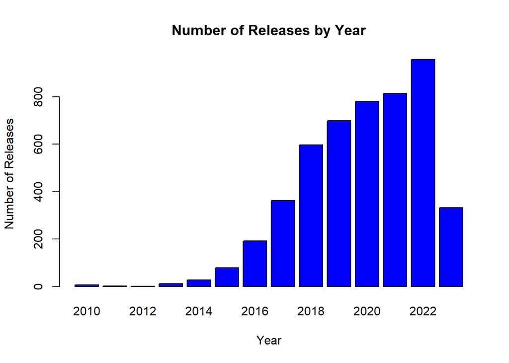

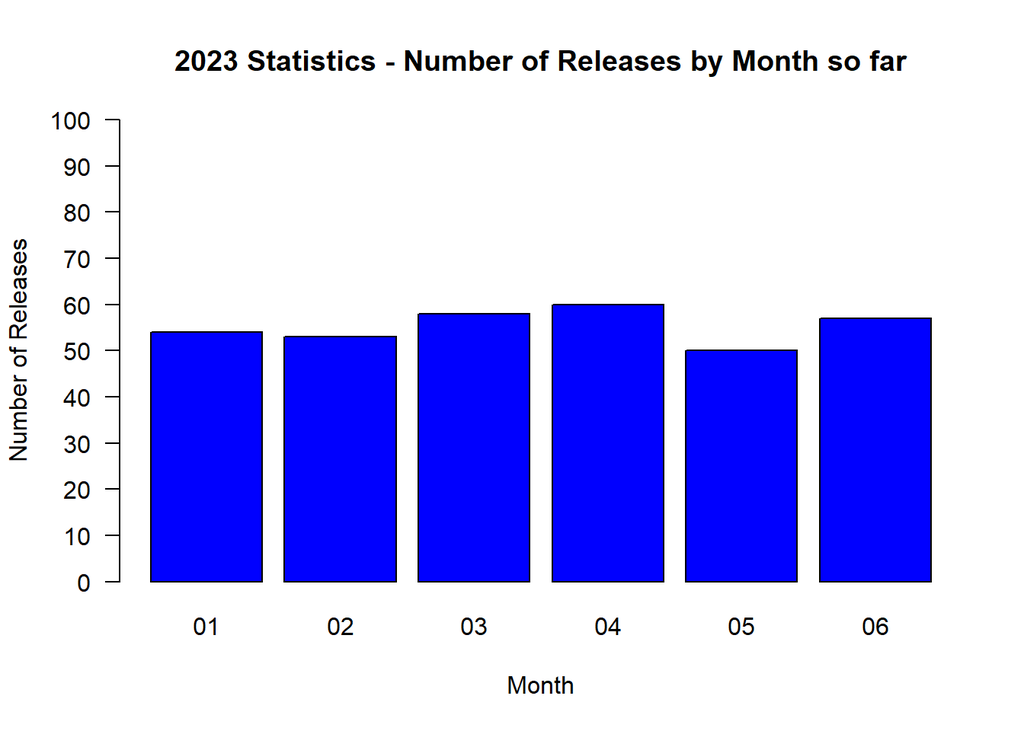

Yukarıdaki grafik, 2023 yılına kadar aylık olarak yapılan yayınların sayısını göstermektedir. Bu durumdan, Netflix’in 2023 yılında sürekli olarak tutarlı bir içerik sunduğu sonucuna varabiliriz.

## İzlenen Saatlerin Ortamaları

| Year | Average Watch Time |
| --- | --- |
| 2021 | 8048280 |
| 2022 | 13929228 |
| 2023 | 51917771 |

İstatistiklere göre, Netflix izleyici sayısı 2023’ün sadece ilk 6 ayında, izlenen saatler açısından 2022’ye kıyasla neredeyse dört katına çıkmıştır.

# Q4 : Veri seti ön işlemesi

## Genre Sütunu

**Genre** sütunu yeniden biçimlendirildi.

Yok Değerler **Genre** sütunundan değiştirildi.

**Genre** sütunu bölündü.

## Key Words Sütunu

**Key Words** Sütunu kaldırıldı.

## Description Sütunu

**Description** Sütunu kaldırıldı.

## Year Sütunu

**Year** Sütunu oluşturuldu.

## Month Sütunu

**Month** Sütunu oluşturuldu.

# Q5 : Veri mühendisliği

Daha iyi temsil için verileri çeyreklere göre gruplandırıldı.

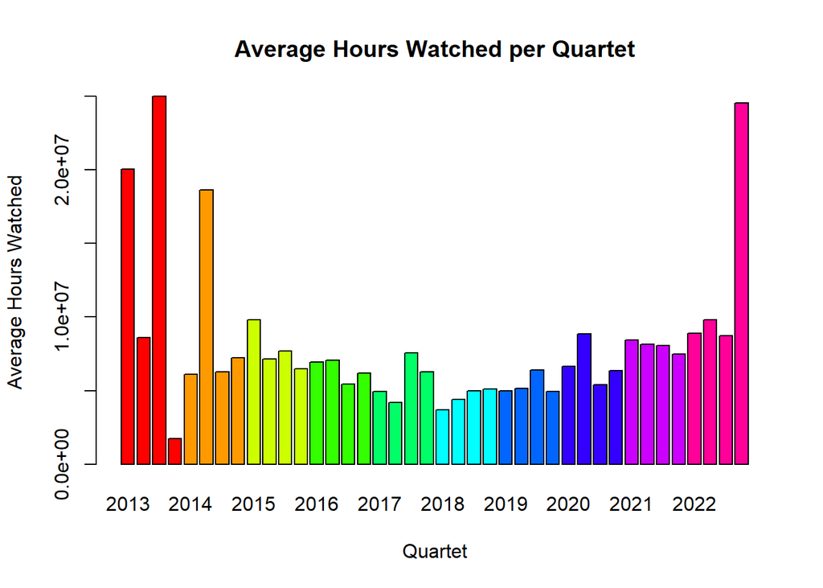

Yukarıdaki grafik, 2013’ten 2022’ye kadar her çeyrekteki ortalama izlenme saatlerini göstermektedir.

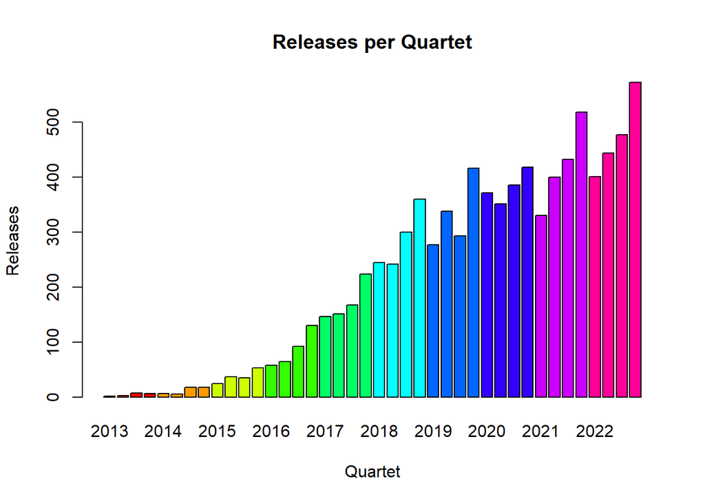